# Tutorial14-numericalIntegration

```python
import numpy as np #importing the numpy library as np
```

## 2 think+type: define some test functions

```python
def parabola(x):
    return (1/2)*x**2 #returing the value inputed squared times 1/2
```

##### testing the parabola function

```python
parabola(2) #this should return 2
```

```
2.0
```

```python
parabola(16) #this should return 128
```

```
128.0
```

```python
parabola(0.5) #this should return 0.125
```

```
0.125
```

the integral of the parabola function((1/2)*x**2) should be ((1/6)*x**3)

```python
def gaussian(x):
    power = (-1)*parabola(x) #I already have (1/2)*x**2 coded in the function parabalo adn this function called for -1/2*x**2 so i'm just going to call parabola inside this function to make it easier
    return np.exp(power)/np.sqrt(2*np.pi)
```

##### testing the gaussian function

```python
parabola(np.sqrt(2)) #getting my parabola function to return 1 or at least a value close to 1
```

```
1.0000000000000002
```

```python
gaussian(np.sqrt(2)) #testing the response of the gausian function with parabola = 1
```

```
0.1467626631737399
```

```python
gaussian(0) #this should make the exponent zero so it should return 1/np.sqrt(2*np.pi)
```

```
0.3989422804014327
```

```python
print(gaussian(0) == (1/np.sqrt(2*np.pi))) #checking my prediction
```

```
True
```

## 3 think+code: integrate using rectangles

#### (aka integrating using Riemann rectangles)

```python
import riemann_rectangles as rect #I named the module, riemann_rectangles.py
# my renamed the model, rectangles.py is so that I don't get confused in the future when I try to find the function for intgrating using riemann rectangles
```

```python
help(rect) #learning what is inside the riemann_rect module
```

```
Help on module riemann_rectangles:

NAME
    riemann_rectangles

FUNCTIONS
    integrateRectangles(f, xmin, xmax, N)
        Approximate the area under the function "f",
        from "xmin" to "xmax", using N rectangles.

        Arguments
            f    : a function to be integrated
            xmin : lower limit of integration
            xmax : upper limit of integration
            N    : number of rectangles to use

        Returns
            the numerical integral of "f"

        Example:
            def integrand(x)
                return x**2
            integrateRectangles(integrand, 0, 1, 5)

    visualizeRectangles(f, xmin, xmax, N)
        Plot "N" rectangles between "xmin" and "xmax",
        to visualize what happens when we calculate
        a rectangular integral of the function "f".

        Arguments
            f    : a function to be integrated
            xmin : lower limit of integration
            xmax : upper limit of integration
            N    : number of rectangles to use

        Returns
            (nothing), but it makes a plot

        Example:
            def integrand(x)
                return x**2
            plotRectangles(integrand, 0, 2, 5)

FILE
    /home/luel8892/ASTR 2600/Tutorial/riemann_rectangles.py
```

Ok, so like the visualizeRectangles function looks really fun, so before I continue with the tutorial, I want to try using the visualizeRectangles function

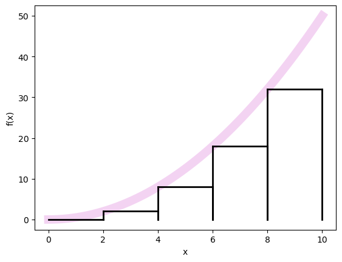

```python
rect.visualizeRectangles(parabola, 0 , 10, 5)
#testing the  visualizeRectangles function with the parabola function
#hopefully this shoiuld return a graph with 5 Riemann rectangles under the curve 1/2*x**2
```

OMG it worked!!!! This is so cool!! (also sorry it looked like just so much fun!)!

```python
# returning to the tutorial steps
x1, x2 = 0.0, 10.0 #setting the bounds of integration

N = 5 #setting the number of rectangles I wanted

def analytic(x1, x2): #creating a function for integrating 1/2*x**2
        return 1/6 * (x2**3 - x1**3) #finding the integral of 1/2*x**2 using the power rule


print('Analytic:')
print(analytic(x1, x2))
```

```
Analytic:
166.66666666666666
```

```python
rect.integrateRectangles(parabola,x1,x2,N) #hopefully this should return a so,o;;ar result to code line [52]
```

```
120.0
```

The correct answer is 500/3, which is equal to 166.6667

let me see if the integrateRectangles function approaches this value as I increase N

```python
rect.integrateRectangles(parabola,x1,x2,10) #this should be greater than 120 as I increased N from 5 to 10
```

```
142.5
```

```python
rect.integrateRectangles(parabola,x1,x2,20) #this should be greater than 142.5 as I increased N from 10 to 20
```

```
154.375
```

woohoo!!! The integrateRectangles function works! As I increase N(the number of rectangles), the integrateRectangles function approaches the value of the continuous integral!

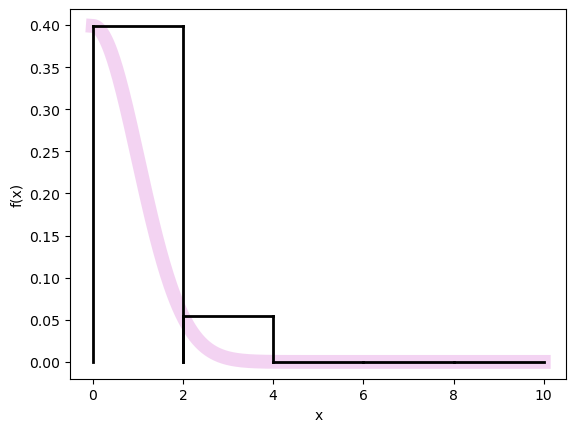

```python
rect.visualizeRectangles(gaussian, 0 , 10, 5)
#testing out the visualizeRectangles function with the gaussian function
```

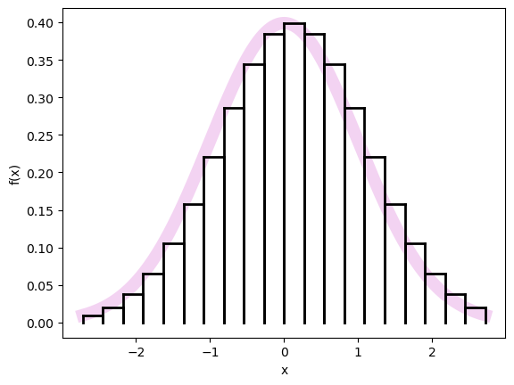

```python
rect.visualizeRectangles(gaussian, -np.e, np.e, 20)
#changing the domain and the number of rectangles to get a prettier graph
#also, I'm noticing that the rectangular integrals are left-bound. I wonder if there is an easy way to switch this to right-bound or midpoint?
```

## 4 think+pair+code: integration using the trapezoids

#### I did this bymysself after class

#### Trapezoidal area formula:

Using Markdown to write mathematical expressions is difficult. This is my best attempt

```python
#code for the area of a trapezoid

def trapezoid(f, x1, x2):
    #area of a trapezoid
    base = x2-x1
    average_height = (f(x1)+f(x2))/2
    area = average_height*base
    return base, average_height, area
```

### trapezoidal integral function

```python
def integrateTrapezoids(f, x1, x2, N):
    '''
    ---inputs-------
    x1 and x2 can be either floats or integers
    N is an integer greater than zero
    f is a defined function

    -------function-------

    The integrateTrapezoids function calculates the trapezoidal
    integral for the function f with N trapezoids between
    x1 and x2

    ------output--------

    The integrateTrapezoids function returns a float
    with 4 decimal places of rounding.

    '''
    delta_area = 0
    base = x2-x1
    trap_integral = 0
    for i in range(0, N):

        #print(area) another testomg print statemet

        current_x = i*(base/N)+x1 #calculating the current value of x with N subdivsions
        x_plus_one = (i+1)*(base/N)+x1 #calculating the value of +1 with N subdivisions
        #area of a trapezium
        delta_base = x_plus_one - current_x #calculating the current base of the trapezoid
        delta_height = (f(x_plus_one)+f(current_x))/2 #calculating the current height of the trapezoid
        delta_area = round(delta_height*delta_base, 4) #the change in the total area under the integral
        trap_integral += delta_area # adding the area for this trapezoid to the total trapezoidal area

        #testing print statements to make sure my function is working
        #print(delta_height)
        #print(delta_base)
        #print(delta_area)

    return trap_integral
```

```python
integrateTrapezoids(parabola, 1, 25, 6) #testing the integrateTrapezoids function
```

```
2636.0
```

```python
integrateTrapezoids(parabola, 1, 28, 8) #testing the integrateTrapezoids function with non-whole numbers to see if my rounding works, it should round to 4 decmil places
```

```
3684.1289
```

my integrateTrapezoids functions seem to be working!

### Trapezoidal visualizer

I figured it would take a lot less time just to edit he function given for visualizeRectangles rather than make my own visualizing function for trapezoids

```python
import numpy as np
import matplotlib.pyplot as plt

def visualizeTrapeziods(f, xmin, xmax, N):
    """

    Plot "N" rectangles between "xmin" and "xmax",
    to visualize what happens when we calculate
    a rectangular integral of the function "f".

    Arguments
        f    : a function to be integrated
        xmin : lower limit of integration
        xmax : upper limit of integration
        N    : number of rectangles to use

    Returns
        (nothing), but it makes a plot

    Example:
        def integrand(x)
            return x**2
        plotRectangles(integrand, 0, 2, 5)
    """

    # first, make a high-resolution plot of the function
    xsmooth = np.linspace(xmin, xmax, 500)
    plt.plot(xsmooth, f(xsmooth), linewidth=10, alpha=0.3, color='orchid')

    # next, make a grid spanning xmin to xmax, with N+1 elements
    x = np.linspace(xmin, xmax, N+1)

    # calculate the offsets from x[:-1] to x[1:]
    dx = np.diff(x)

    # loop over rectangles
    for i in range(N):

        # where are the left and right edges of the rectangle?
        left = x[i]
        right = x[i] + dx[i]

        # set the rectangle plotting style
        plotkw = dict(color='black', linewidth=2)

        # plot vertical line from 0 up to the curve (left edge of rectangle)
        plt.plot([left, left], [0, f(left)], **plotkw)

        # plot another vertical line (right edge of rectangle)
        plt.plot([right, right], [0, f(right)], **plotkw)

        # plot horizontal line (top of rectangle)
        plt.plot([left, right], [f(left), f(right)], **plotkw) #the only thing i changed was,  [f(left), f(left)] to  [f(left), f(right)] now it plots trapezoidal areas

    # set the x and y labels
    plt.xlabel('x')
    plt.ylabel('f(x)')

    # make sure the plot displays to the screen
    plt.show()
```

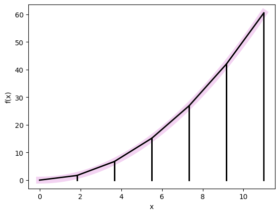

```python
 visualizeTrapeziods(parabola, 0, 11, 6)
```

### comparing analytical, rectangular, and trapezoidal integration of the parabola

```
Testing <function parabola at 0x7f5048383380>
Analytic: 166.66666666666666
Rectangular: 120.0
Trapezoids: 170.0
```

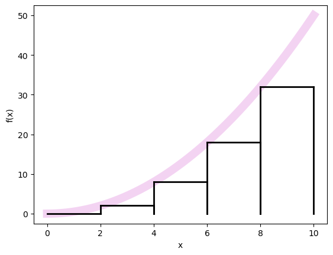

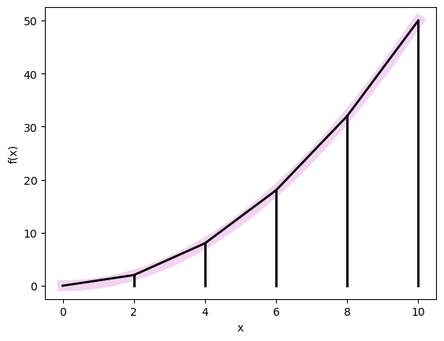

```python
# final print statements for my trapezoidal integral stuff

print("Testing", parabola)
print('Analytic:', analytic(x1, x2))
print('Rectangular:', rect.integrateRectangles(parabola,x1,x2,N))
print("Trapezoids:", integrateTrapezoids(parabola, x1, x2, N))
rect.visualizeRectangles(parabola, 0 , 10, 5) #throwing in the rectangular integral visualizer to compare with my trapeziodal integral visualizer
visualizeTrapeziods(parabola, x1, x2, N)
```

All 3 of the answers look quite similar. The rectangular is clearly an underestimate, and the trapezoidal is an overestimate. This makes sense since the curve y = x^2 is concave up and increasing on the interval tested. A left-bound rectangular approximation would be an underapproximation, and a trapezoidal approximation would be an overestimate. *** Please note that I do not know how to prove why this is true because I have not yet taken any course involving proofs or analysis

### comparing rectangular and trapezoidal integration of the Gaussian

##### no analytical because idk how to analytically integrate the Gaussian function

```
Testing <function gaussian at 0x7f5048139d00>
Rectangular: 1.0143837720622289
Trapezoids: 1.0142
```

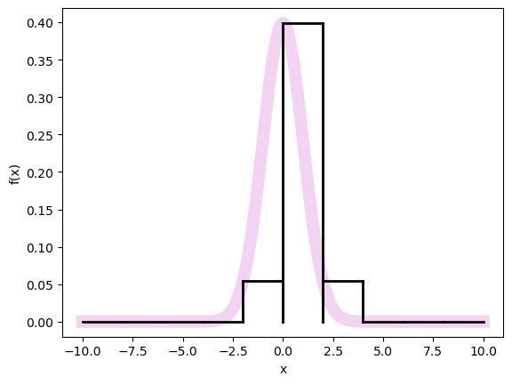

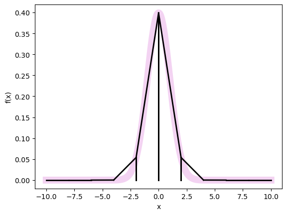

```python
print("Testing", gaussian)
N = 10
x1 = -10 # redefining x1 to -10, that way the gaussian function looks beter and I can see that "bell" curve
print('Rectangular:', rect.integrateRectangles(gaussian,x1,x2,N))
print("Trapezoids:", integrateTrapezoids(gaussian, x1, x2, N))
rect.visualizeRectangles(gaussian, x1, x2, N) #throwing in the rectangular integral visualizer to compare with my trapeziodal integral visualizer
visualizeTrapeziods(gaussian, x1, x2, N)
```

since both approximations are pretty similar(they only begin to vary at the ten-thousandths place) and both graphs appear to be pretty similar, I believe my functions worked successfully!

# 5 (bonus)+think+type: converging with N

```
0 0
```

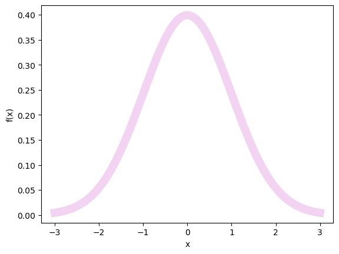

```
1 0.0266
```

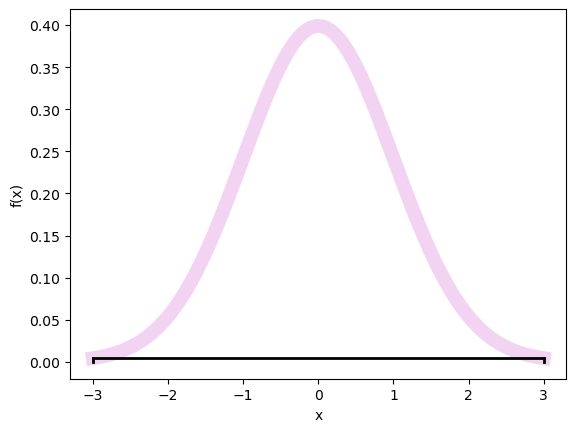

```
2 1.2102
```

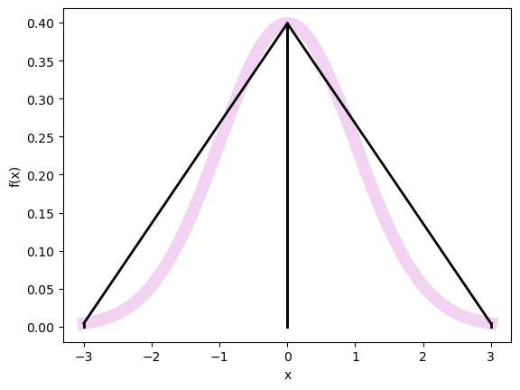

```
3 0.9766999999999999
```

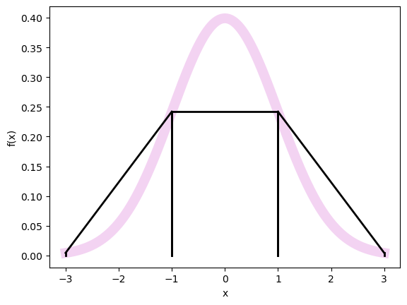

```
4 0.9936
```

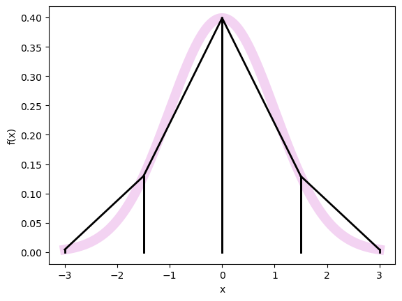

```
5 0.9945
```

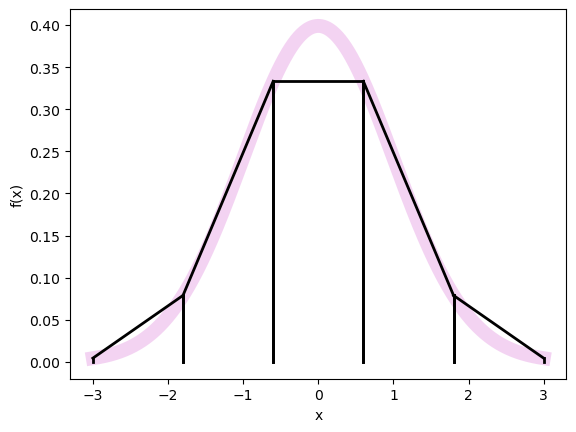

```
6 0.9954000000000001
```

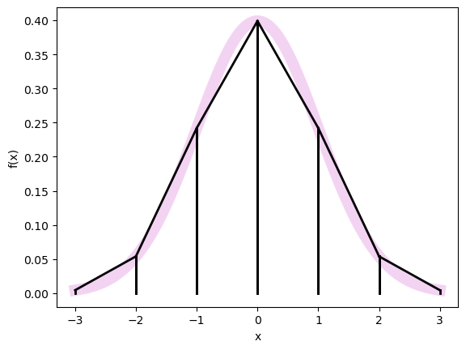

```
7 0.9956999999999999
```

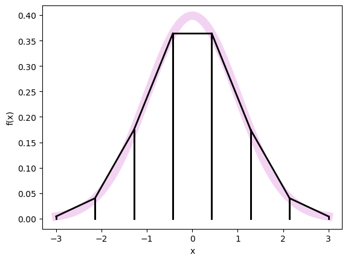

```
8 0.9961999999999999
```

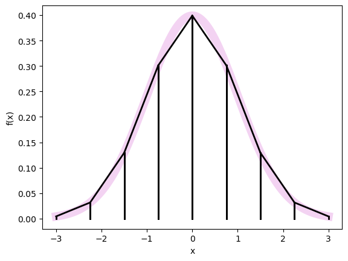

```
9 0.9964
```

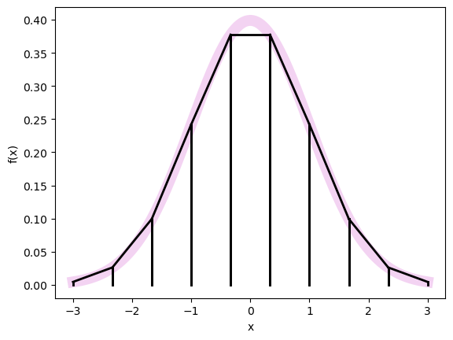

```
10 0.9964
```

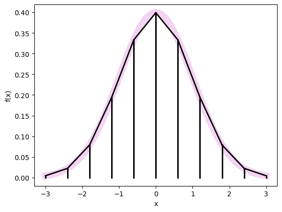

```
11 0.9967
```

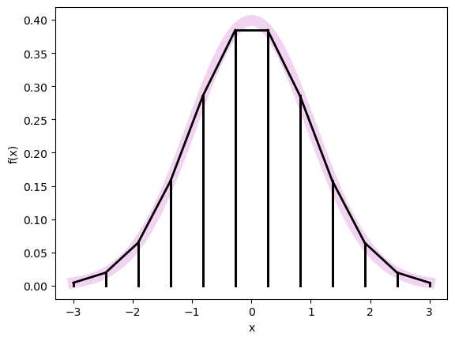

```
12 0.9969999999999999
```

[12 more figures not shown]

```python
x1, x2 = -3, 3 #setting the interval


#for N in 2**np.arange(23): idk why this code isn't working so I'm rewriting it to make sense to me
for N in np.arange(24): #creates ann array from 0 to 24


    inputs = [gaussian, x1, x2, N]

    print(N, integrateTrapezoids(*inputs)) #putting the list of inputs (N) into the trapoziodal integral function

# only plot if N is small (otherwise it takes forever!)
    if N < 100:
        visualizeTrapeziods(*inputs)
```